# Course evaluations and linear regression

Derien W

M6 ICA2

# Introduction

This is adapted from Lab 6 in Duke’s Introduction to Data Science course.

We will analyze what goes into course evaluations and how certain variables effect the overall score.

To get started, load packages `tidyverse` and `broom`. Install any packages with code `install.packages("package_name")`.

```r
library(tidyverse)
library(broom)
library(dplyr)
```

# Data

The data were gathered from end of semester student evaluations for a large sample of professors from the University of Texas at Austin. In addition, six students rated the professors’ physical appearance. Each row in `evals` contains a different course and the columns represent variables about the courses and professors.

Use `read_csv()` to read in the data and save it as an object named `evals`. The data is available on D2L.

```r
evals <- read_csv("evals-mod.csv")
```

## Data dictionary

| **Variable** | **Description** |
| --- | --- |
| score | Average professor evaluation score: (1) very unsatisfactory - (5) excellent |
| rank | Rank of professor: teaching, tenure track, tenure |
| ethnicity | Ethnicity of professor: not minority, minority |
| gender | Gender of professor: female, male |
| language | Language of school where professor received education: english or non-english |
| age | Age of professor |
| cls_perc_eval | Percent of students in class who completed evaluation |
| cls_did_eval | Number of students in class who completed evaluation |
| cls_students | Total number of students in class |
| cls_level | Class level: lower, upper |
| cls_profs | Number of professors teaching sections in course in sample: single, multiple |
| cls_credits | Number of credits of class: one credit (lab, PE, etc.), multi credit |
| bty_f1lower | Beauty rating of professor from lower level female: (1) lowest - (10) highest |
| bty_f1upper | Beauty rating of professor from upper level female: (1) lowest - (10) highest |
| bty_f2upper | Beauty rating of professor from upper level female: (1) lowest - (10) highest |
| bty_m1lower | Beauty rating of professor from lower level male: (1) lowest - (10) highest |
| bty_m1upper | Beauty rating of professor from upper level male: (1) lowest - (10) highest |
| bty_m2upper | Beauty rating of professor from upper level male: (1) lowest - (10) highest |

Before you get started, add the `avg_bty` variable.

```r
evals <- evals %>%
  rowwise() %>%
  mutate(avg_bty = mean(bty_f1lower:bty_m2upper)) %>%
  ungroup()
```

# Part 1

## Categorical predictors

#### Task 1

Fit a linear model with `score` as the response and `language` as a single predictor. Write out the model output.

```r
mod.fit <- lm(score ~ as.factor(language), data = evals)
mod.fit
```

```
Call:
lm(formula = score ~ as.factor(language), data = evals)

Coefficients:
                   (Intercept)  as.factor(language)non-english
                        4.1897                         -0.2468
```

#### Task 2

What is the baseline level in Task 1? Interpret the meaning of coefficient $b_1$. #b1 is -0.24 which that means each increase in the other explanatory variable is associated with a fall in outcome that is equal in magnitude to the abs value of b1 #### Task 3

Based on Task 1, what is the equation of the line for English speaking professors? What about non-English speaking professors? #English speakers: y = 4.18 + -0.24 x english #Non-English speakers: y = 4.18 + -0.24 x non-english

#### Task 4

Create a scatter plot of `score` versus `rank` with `ggplot()`. Use `geom_jitter()`.

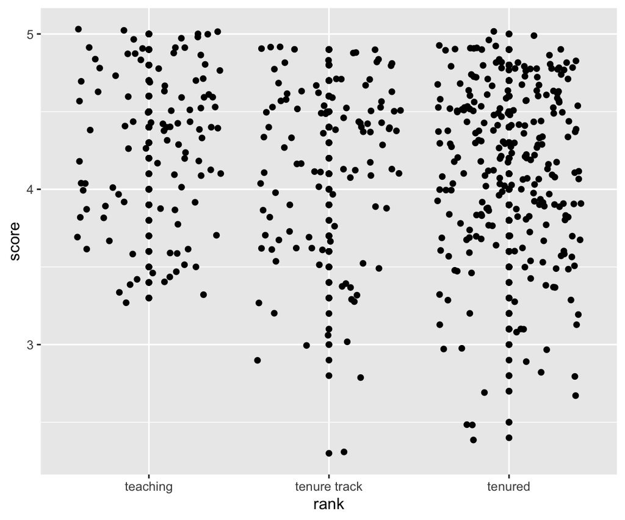

```r
ggplot(data = evals, aes(x=rank, y=score)) + geom_point() + geom_jitter()
```

#### Task 5

Fit a linear model with `score` as the response and `rank` as a single predictor. What is the baseline? Write out the model output.

```r
mod.fit1 <- lm(score ~ rank, data = evals)
mod.fit1
```

```
Call:
lm(formula = score ~ rank, data = evals)

Coefficients:
     (Intercept)  ranktenure track       ranktenured
          4.2843           -0.1297           -0.1452
```

```r
# The baseline is 4.28
```

#### Task 6

Add a new variable to `evals` called `rank_new` where the baseline level is set to “tenured”. *Hint*: `relevel()`

```r
evals$rank_new <- relevel(factor(evals$rank), ref="tenured")
```

#### Task 7

Fit a linear model with `score` as the response and `rank_new` as a single predictor. Is the baseline now different from the baseline in Task 5?

```r
m3.evals.fit <- lm(score~factor(rank_new), data=evals)
m3.evals.fit
```

```
Call:
lm(formula = score ~ factor(rank_new), data = evals)

Coefficients:
                 (Intercept)      factor(rank_new)teaching
                      4.1391                        0.1452
factor(rank_new)tenure track
                      0.0155
```

```r
# Yes it is slightly different now
```

# Part 2

## Multiple regression

#### Task 8

Fit a linear model with `score` as the response and `gender`, `rank`, and `avg_bty` as predictors. Write out the model. Give an interpretation for the coefficient of `avg_bty`.

```r
mod.fit2 <-  lm(score ~ gender + rank + avg_bty, data = evals)
mod.fit2
```

```
Call:
lm(formula = score ~ gender + rank + avg_bty, data = evals)

Coefficients:
     (Intercept)        gendermale  ranktenure track       ranktenured
         3.96135           0.17118          -0.09396          -0.15646
         avg_bty
         0.05088
```

```r
# The avg_bty coefficient describes the expected differences between score in that specific rank and gender compared to the baseline level
```

#### Task 9

What are the $R^2$ and adjusted $R^2$ values from your model in Task 8?

```r
require(MASS)
require(dplyr)

evals1 <- lm(score ~ gender + rank + avg_bty, data = evals)
  evals1 %>%
  glance() %>%
  dplyr::select(r.squared, adj.r.squared)
```

| r.squared | adj.r.squared |
| --- | --- |
| 0.05343843 | 0.04517152 |

#### Task 10

Fit a linear model with `score` as the response and only `gender` and `avg_bty` as predictors. How did the $R^2$ and adjusted $R^2$ values change compared to Task 9?

```r
mod.fit3 <-  lm(score ~ gender + avg_bty, data = evals)
mod.fit3
```

```
Call:
lm(formula = score ~ gender + avg_bty, data = evals)

Coefficients:
(Intercept)   gendermale      avg_bty
    3.84876      0.14896      0.05502
```

```r
evals2 <- lm(score ~ gender + avg_bty, data = evals)
  evals2 %>%
  glance() %>%
  dplyr::select(r.squared, adj.r.squared)
```

| r.squared | adj.r.squared |
| --- | --- |
| 0.04079587 | 0.03662542 |

```r
  #The R^2 values are a little bit less this time around.
```

## Model Selection

#### Task 11

Fit a full model with `score` as the response and predictors: `rank`, `ethnicity`, `gender`, `language`, `age`, `cls_perc_eval`, `cls_students`, `cls_level`, `cls_profs`, `cls_credits`, `bty_avg`.

```r
full.model <-   lm(score ~ factor(rank) + factor(ethnicity) + factor(gender) +
                     factor(language) + age + cls_perc_eval + cls_students +
                     factor(cls_level) + factor(cls_profs) +
                     factor(cls_credits) + avg_bty,
                   data = evals)
full.model
```

```
Call:
lm(formula = score ~ factor(rank) + factor(ethnicity) + factor(gender) +
    factor(language) + age + cls_perc_eval + cls_students + factor(cls_level) +
    factor(cls_profs) + factor(cls_credits) + avg_bty, data = evals)

Coefficients:
                  (Intercept)       factor(rank)tenure track
                    3.6337433                     -0.0928709
          factor(rank)tenured  factor(ethnicity)not minority
                   -0.0404267                      0.1758938
           factor(gender)male    factor(language)non-english
                    0.1702736                     -0.1224725
                          age                  cls_perc_eval
                   -0.0082217                      0.0061850
                 cls_students         factor(cls_level)upper
                    0.0005724                      0.0192594
      factor(cls_profs)single  factor(cls_credits)one credit
                   -0.0117447                      0.5081555
                      avg_bty
                    0.0480446
```

#### Task 12

Why did we not consider `cls_did_eval` and the individual beauty scores? # Because we have cls_perc_eval and avg_bty scores to be a greater representation

#### Task 13

Use the fitted full model in Task 11 and backward selection to determine the “best”" model. What are the $R^2$ and adjusted $R^2$ values from this “best” model?

```r
require(MASS)
require(dplyr)
best.model <- step(object = full.model, direction = "backward", trace = TRUE)
```

```
Start:  AIC=-617.37
score ~ factor(rank) + factor(ethnicity) + factor(gender) + factor(language) +
    age + cls_perc_eval + cls_students + factor(cls_level) +
    factor(cls_profs) + factor(cls_credits) + avg_bty

                      Df Sum of Sq    RSS     AIC
- factor(rank)         2    0.3231 115.69 -620.07
- factor(cls_profs)    1    0.0132 115.39 -619.31
- factor(cls_level)    1    0.0305 115.40 -619.24
- factor(language)     1    0.3265 115.70 -618.06
<none>                             115.37 -617.37
- cls_students         1    0.6613 116.03 -616.72
- factor(ethnicity)    1    1.3064 116.68 -614.15
- age                  1    1.8751 117.25 -611.90
- avg_bty              1    2.3646 117.74 -609.97
- factor(gender)       1    2.7778 118.15 -608.35
- cls_perc_eval        1    4.1160 119.49 -603.14
- factor(cls_credits)  1    4.7639 120.14 -600.63

Step:  AIC=-620.07
score ~ factor(ethnicity) + factor(gender) + factor(language) +
    age + cls_perc_eval + cls_students + factor(cls_level) +
    factor(cls_profs) + factor(cls_credits) + avg_bty

                      Df Sum of Sq    RSS     AIC
- factor(cls_profs)    1    0.0178 115.71 -622.00
- factor(cls_level)    1    0.0202 115.72 -621.99
- factor(language)     1    0.4975 116.19 -620.09
<none>                             115.69 -620.07
- cls_students         1    0.6313 116.33 -619.55
- factor(ethnicity)    1    1.4853 117.18 -616.17
- age                  1    1.7870 117.48 -614.98
- avg_bty              1    2.6094 118.31 -611.75
- factor(gender)       1    2.8617 118.56 -610.76
- cls_perc_eval        1    4.1953 119.89 -605.58
- factor(cls_credits)  1    5.6278 121.32 -600.08

Step:  AIC=-622
score ~ factor(ethnicity) + factor(gender) + factor(language) +
    age + cls_perc_eval + cls_students + factor(cls_level) +
```

[output cut: 28 more lines]

```
- factor(cls_credits)  1    6.2182 121.95 -601.70

Step:  AIC=-624.02
score ~ factor(ethnicity) + factor(gender) + age + cls_perc_eval +
    cls_students + factor(cls_credits) + avg_bty

                      Df Sum of Sq    RSS     AIC
<none>                             116.21 -624.02
- cls_students         1    0.7262 116.94 -623.14
- age                  1    1.7961 118.01 -618.92
- factor(ethnicity)    1    2.5168 118.73 -616.10
- avg_bty              1    2.5963 118.81 -615.79
- factor(gender)       1    2.7355 118.94 -615.25
- cls_perc_eval        1    4.2850 120.49 -609.25
- factor(cls_credits)  1    6.6934 122.90 -600.09
```

```r
best.model %>% tidy()
```

| term | estimate | std.error | statistic | p.value |
| --- | --- | --- | --- | --- |
| (Intercept) | 3.4647977658 | 0.2000160091 | 17.322602 | 5.331083e-52 |
| factor(ethnicity)not minority | 0.2242588169 | 0.0714391664 | 3.139158 | 1.804551e-03 |
| factor(gender)male | 0.1651058300 | 0.0504496615 | 3.272685 | 1.146431e-03 |
| age | -0.0067324918 | 0.0025387676 | -2.651874 | 8.284173e-03 |
| cls_perc_eval | 0.0062800673 | 0.0015332194 | 4.096000 | 4.975914e-05 |
| cls_students | 0.0005731697 | 0.0003399236 | 1.686172 | 9.244816e-02 |
| factor(cls_credits)one credit | 0.5376737936 | 0.1050290341 | 5.119287 | 4.534583e-07 |
| avg_bty | 0.0496457010 | 0.0155710788 | 3.188328 | 1.529679e-03 |

```r
  best.model %>%
  glance() %>%
  dplyr::select(r.squared, adj.r.squared)
```

| r.squared | adj.r.squared |
| --- | --- |
| 0.1496099 | 0.136527 |

## Inference

#### Task 14

Create a 95% prediction interval based on new predictor values of your choosing. Use your “best” model from Task 13.

```r
new.data <- tibble(ethnicity="minority", gender="male", age=45, cls_perc_eval=.8, cls_students=50,
                   cls_credits="one credit", avg_bty=5)
predict(best.model, newdata=new.data, interval="prediction", level=.95)
```

```
       fit      lwr      upr
1 4.146526 3.100137 5.192915
```

#### Task 15

Create 95% confidence intervals for the coeffients of your “best”" model from Task 13.

```r
best.model %>% broom::confint_tidy(conf.level = .95)
```

| conf.low | conf.high |
| --- | --- |
| 3.071728e+00 | 3.857867512 |
| 8.386718e-02 | 0.364650454 |
| 6.596259e-02 | 0.264249072 |
| -1.172166e-02 | -0.001743328 |
| 3.266998e-03 | 0.009293137 |
| -9.484521e-05 | 0.001241185 |
| 3.312716e-01 | 0.744075951 |
| 1.904555e-02 | 0.080245852 |

#### Task 16

Can we use this model to make valid predictions about professors from any University? # It’s likely to not use this model to make valid predictions about professor s from any university. This model + predictions comes from professors of UTA. Doing predictions anywhere else would be extrapolation.

# References

1. http://www2.stat.duke.edu/courses/Spring18/Sta199/labs/lab-06-modelling-course-evals.html